# 1 ggPlot2

# 2 Sintaxis de ggplot2

Previamente a la creación de gráficos con ggplot2 o cualquier otro software, es importante que definas el objetivo de crear un gráfico y conozcas la naturaleza de las variables a graficar (categóricas, numéricas, discretas, continuas…), así como su distribución.

La sintaxis para elaborar gráficos en **`ggplot2`** se compone de los siguientes elementos:

- 1. Datos: *data frame* y las variables a graficar (*aesthetics*)
- 2. Geometría: Tipo de gráfico (histogramas, de barras, de puntos, de lineas, pastel, cajas/bigotes…)
- 3. Estadisticos: Transformaciones estadísticas que resumen los datos (media, mediana, intervalos de confianza)
- 4. Escalas: Títulos de los ejes y valores para modificar la estética (color, forma, tamaño) de los datos
- 5. Sistema de coordenadas: El plano en el cual se está graficando
- 6. Paneles: Valor opcional si se desean crear multiples gráficas a partir de variables categóricas

## 2.1 Datos y *aesthetics*

Para crear un gráfico en **`ggplot2`**, se requiere utilizar la función `ggplot()` y dentro de ella especificar el *data frame* que contiene los datos. En el argumento `aes()` se indican las variables (x y) a graficar. Como ejemplo utilizaremos el *data set* **`mpg`**

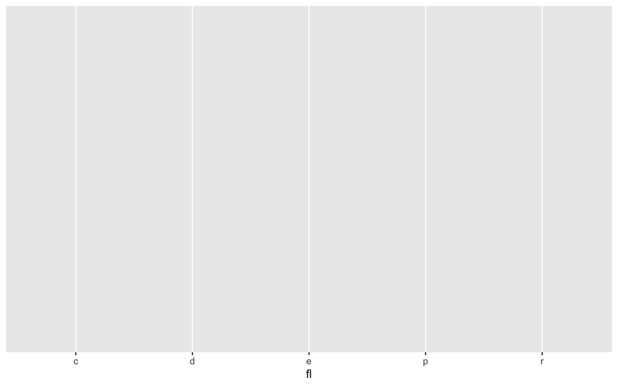

```r
##Utiliza la función ggplot para crear un gráfico de una variable fl
ggplot(mpg, aes(x = fl))
```

De esta manera se produce una gráfica de un solo plano en donde se visualizan los ejes x/y y la variable fl en x. Sin embargo, no hay ningún dato graficado.

## 2.2 Geometría

Para graficar los datos se requiere adicionar una capa utilizando un símbolo **+** seguidamente de la función `ggplot()`:

```r
##Genera una gráfica de puntos con los comandos previamente utilizados
ggplot(mpg, aes(x = hwy)) +
  geom_histogram()
```

[output not shown]

### 2.2.1 Una variable continua

Para graficar una sola variable continua, utilizaremos las funciones `geom_histogram()` y `geom_density()`

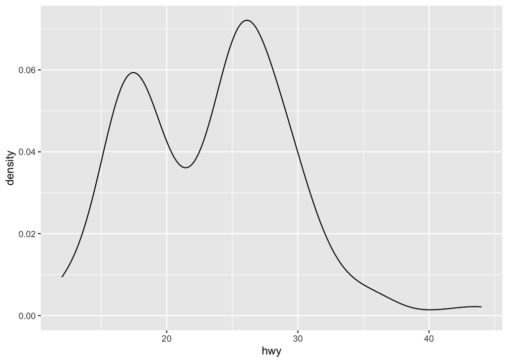

```r
##Graficar la frecuencia en la distribución del Sepal.Length
ggplot(mpg, aes(x = hwy)) +
  geom_histogram()
##Graficar la densidad en la distribución del Sepal.Length
ggplot(mpg, aes(x = hwy)) +
  geom_density()
```

[output not shown]

En el caso de tener una variable categórica o discreta se emplea la función `geom_bar()`:

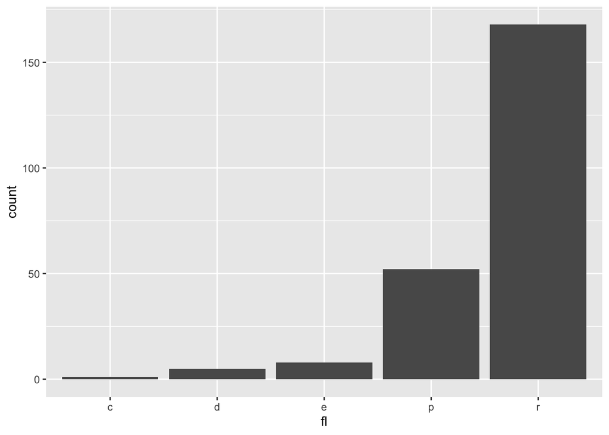

```r
##Crear una gráfica de barras de acuerdo al tipo de combustible de los autos
ggplot(mpg, aes(x = fl)) +
  geom_bar()
```

### 2.2.2 Dos variables

Cuando los datos provienen de dos variables contínuas, se emplea el gráfico de puntos o *scatter plot* con la función `geom_point()`.

```r
##Graficar las millas recorridas por galón de combustible en ciudad o carretera
ggplot(mpg, aes(x = cty, y = hwy)) +
  geom_point()
```

[output not shown]

Los atributos para modificar el color de relleno, contorno, la forma y el tamaño de los puntos indican con dentro del comando `geom_point()`:

El color de relleno de los datos se indica entre comillas empleando los nombres de los colores contenidos dentro de esta esta lista:

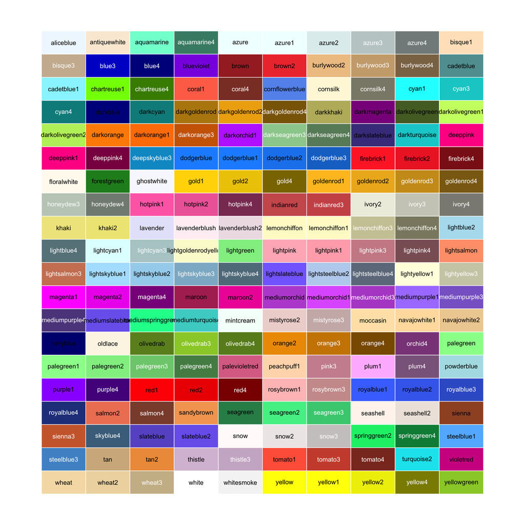

Sin embargo, la lista no está limitada a estos colores. Puedes utilizar el valor hexadecimal del color que más te guste. Para ello, consulta la página [color.co](https://coolors.co/) para generar paletas de colores y obtengas el valor hexadecimal

[figure not shown]